# TD Théorie de l'information 1

## Exercice 0 Etude de la fonction $x.log_2(x)$

## Graphe de la fonction

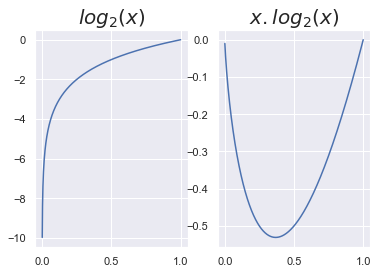

```python
%matplotlib inline
import matplotlib.pyplot as plt
import seaborn as sns
sns.set(style="darkgrid")

import warnings
warnings.simplefilter("ignore")

import numpy as np
from math import *
from sympy import init_printing
from sympy.plotting import plot

init_printing()

fig, (ax1,ax2) = plt.subplots(nrows=1, ncols=2)

x=np.linspace(0.000,1,1000)
ax1.plot(x,np.log2(x))  # utiliser np. car c'est la fonction log2 vectorisée de numpy
#ax1.ylabel("$log_2(x)$")
#ax1.xlabel("$x$")
ax1.set_title("$ log_2(x) $",fontsize=20)
ax2.plot(x,x*np.log2(x))  # utiliser np. car c'est la fonction log2 vectorisée de numpy
ax2.set_title("$ x.log_2(x)$",fontsize=20)
```

se rappeler que $\lim_{x\to0} x.ln(x)=0$ et que $\log_2(x)=\frac{ln(x)}{ln(2)}$. Quand on ne précise pas la base de log, supposer que c'est le log à base e c'est à dire ln.

## Calcul de la dérivée

```python
from sympy import * # Librarie de calcul symbolique
x = symbols('x')
from IPython.display import display
# ci-dessous on re-ecrit log2(x) comme log(x)/log(2) pour aider sympy
display(simplify(diff(x*log(x)/log(2), x)) )  # Calcul de la derivee
```

$\displaystyle \frac{\log{\left(x \right)} + 1}{\log{\left(2 \right)}}$

## Trouver quand cette dérivée s'annule

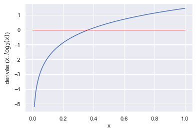

```python
t=np.linspace(0.01,1,100)
plt.plot(t,(np.log(t)+1)/np.log(2))
plt.plot([0, 1], [0, 0], color='r', linestyle='-', linewidth=1)
plt.ylabel('derivée ($x.log_2(x)$)')
plt.xlabel("x")
plt.show()
```

```python
display(solve((log(x) + 1)/log(2),x))  # solve résoud l'équation (expression)=0 par rapport à la variable passée en 2eme paramètre
```

$\displaystyle \left[ e^{-1}\right]$

## Exercice 0.5 : la pièce à pile ou face, plus ou moins truquée

##### Ici on tire une pièce plus ou moins truquée et **on calcule l'entropie de cette pièce** selon la proba p de tirer pile (et proba 1-p de tirer face). L'entropie est au maximum pour p=0.5 (la distribution de probabilité est alors la plus proche de la distribution uniforme)

$\displaystyle - \frac{p \log{\left(p \right)}}{\log{\left(2 \right)}} - \frac{\left(1 - p\right) \log{\left(1 - p \right)}}{\log{\left(2 \right)}}$

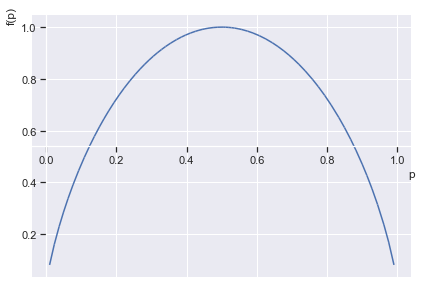

```
<sympy.plotting.plot.Plot at 0x7fe5f83e5b50>
```

```python
p = symbols('p')
entropie = -1* (p*log(p)/log(2) + (1-p)*log(1-p)/log(2))
display(entropie)
plot(entropie,(p,0.01,0.99))
```

On calcule maintenant la dérivée de cette entropie pour regarder quand l'entropie maximale

$\displaystyle \frac{- \log{\left(p \right)} + \log{\left(1 - p \right)}}{\log{\left(2 \right)}}$

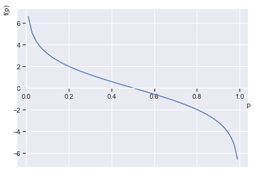

```
<sympy.plotting.plot.Plot at 0x7fe5f8455730>
```

```python
from sympy.plotting import plot
p = symbols('p')
derivee_entropie=simplify(diff(entropie))
display(derivee_entropie)
plot(derivee_entropie,(p,0.01,0.99))
```

On cherche maintenant quand la dérivée s'annule en utilisant la fonction solve et on constate que l'entropie de la pièce est maximisée pour une pièce non truquée c.a.d. p =1/2, comme le montrait la figure précédente

```python
display(solve(derivee_entropie,p))
```

$\displaystyle \left[ \frac{1}{2}\right]$

# Exercice 1

Si on appelle $a_i$ l'événement "c'est la face $a_i$" qui est tirée et $p(a_i)$ la probabilité de cet événement.

- l'information retournée par la réalisation d'une face est $I(a_i)=-log_ 2( p(a_i) )$=2.58 pour un dé régulier
- $I(a_1)=-log_ 2( p )$ et $I(a_j)=-log_ 2( \frac{(1-p)}{5} )$ où $j=2,\dots,6$

Attention maintenant avec l'entropie on mesure une caractéristique du dé et non plus d'un tirage spécifique d'une de ses faces

$$H(dé)= -p.log_ 2( p ) - \sum_{i=2,\dots,6} \frac{(1-p)}{5} log_ 2( \frac{(1-p)}{5} ) $$

# Exercice 2

Etant donné un nombre secret s, le choix d'un nombre n par le devineur correspond à une source dont un tirage produit 3 événéments possibles :

- "trop grand" : 0<=s<n (n chances sur 100)
- "gagné" : 1 (1 chance sur 100)
- "trop petit" : n+1<s<=99 (99-n chances sur 100)

On vérifie bien que la somme fait bien 100 chances sur 100 ! De là, on peut calculer l'entropie.

```
(-0.01*n*log(n) + 0.01*n*log(0.99 - 0.01*n) + 0.0460517018598809*n - 0.99*log(0.99 - 0.01*n) + 0.0460517018598809)/log(2)
(-0.0001*n/(0.99 - 0.01*n) - 0.01*log(n) + 0.01*log(0.99 - 0.01*n) + 0.0360517018598809 + 0.0099/(0.99 - 0.01*n))/log(2)
```

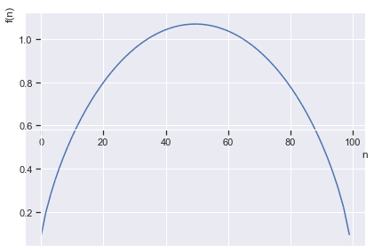

```
<sympy.plotting.plot.Plot at 0x7fe5d9f74e20>
```

```python
from sympy import Array
from sympy.abc import n
from sympy.functions import log

# Voici les 3 probas correspondant à chacun de nos 3 événements
tableau_probas = 0.01 * Array([n, 1, 99-n] )

# on applique
tp=tableau_probas.applyfunc(lambda a:-1*a*log(a,2))



resu=simplify(expand(sum(tp)))
print(resu)
der = diff(resu)
print(der)
plot(resu,(n,0.1,98.9))
```

L'entropie (et donc l'information) est maximale quand on propose 50.

Cet exercice a aussi un rapport avec ce que vous étudiez en bases de données : comment organiser les données en sous-parties (par exemple avec un arbre) telle qu'une interrogation rapportera le maximum d'information (en moyenne) sur la localisation d'une donnée ou d'une autre des sous-parties et, le principe étant appliqué récursivement, minimise le coût moyen des opérations pour atteindre la dite donnée.

# Exercice 3

Calcul de l'entropie (sans approximation) :

```python
tableau_probas  = [1/64,1/32,1/16,1/4,17/32,1/16,1/32,1/64]
print(sum(list(map(lambda x: -x*np.log2(x), tableau_probas))))
```

```
1.9847853655857572
```

A la place, on aurait pu utiliser une fonction fournie par la librairie python scipy

```python
from scipy.stats import entropy
print (entropy(tableau_probas,base=2))
```

```
1.9847853655857575
```

Si on veut faire l'opération à la main, pour se simplifier les calculs on approxime 17/32 par 16/32 et on obtient :

```python
tableau_probas_approximation  = [1/64,1/32,1/16,1/4,16/32,1/16,1/32,1/64]
print(sum(list(map(lambda x: -x*np.log2(x), tableau_probas_approximation))))
```

```
2.0
```

### Code à virgule

Rangeons les probabilité de la plus grande à la plus petite et associons leur (dans cet ordre) les codes binaires suivants :

- 0
- 01
- 001
- 0001
- 00001
- 000001
- 0000001
- 00000001

Ainsi les symboles les plus fréquents ont les séquences binaires les plus courtes

```python
probas    = [17/32,1/4,1/16,1/16,1/32,1/32,1/64,1/64]
longueurs = [1,2,3,4,5,6,7,8]
longueur_code_virgule =np.dot(probas,longueurs) # dot calcule la somme des produits
print(longueur_code_virgule)
```

[output not shown]

### Huffmann

L'algorithme donne :

- 0:00000 ( de longueur 5)
- 7:00001
- 1:00010
- 6:00011
- 2:0010
- 5:0011
- 3:01
- 4:1 (de longueur 1)

```python
longueur_code_huffmann = 5/64+5/64+5/32+5/32+4/16+4/16+2/4+17/32
print(longueur_code_huffmann)
```

```
2.0
```

```python
longueur_code_huffmann = 6/64+6/64+5/32+4/32+4/16+4/16+2/4+17/32
print(longueur_code_huffmann)
```

[output not shown]

## Shannon-Fano

donne :

- 0:00000
- 7:00001
- 1:00010
- 6:00011
- 2:0010
- 5:0011
- 3:01
- 4:1

où on voit qu'on obtient le même code que avec Huffmann (donc la même longueur moyenne) mais c'est plutôt l'exception que la situation la plus courante. On obtient une performance très proche de l'entropie mais, là aussi, c'est un cas assez particulier.

```python
3/2-17/32*log2(17/32)
```

```python
3/2+1/2*log2(2)
```